-Objective:Understanding the reasons behind the major crimes and predicting where crimes may occur and therefore to prevent further occurrences.

-Data Acquisition and Reshaping:

-Two csv files -reading the first file which contain data about crime history from 2010 to 2018.

```r
library(data.table)
setwd("~/GitHub/Machine-Learning/R/London-Crimes")
history=fread("MPS_Ward_Level_Crime_Historic_NewWard.csv", header = T,sep = ",", dec = ".")
head(history)
```

```
##     WardCode       WardName              Borough MajorCategory
## 1: E05000026          Abbey Barking and Dagenham      Burglary
## 2: E05000027         Alibon Barking and Dagenham      Burglary
## 3: E05000028      Becontree Barking and Dagenham      Burglary
## 4: E05000029 Chadwell Heath Barking and Dagenham      Burglary
## 5: E05000030      Eastbrook Barking and Dagenham      Burglary
## 6: E05000031       Eastbury Barking and Dagenham      Burglary
##             MinorCategory T_201004 T_201005 T_201006 T_201007 T_201008 T_201009
## 1: Burglary In A Dwelling        9        4        6        6       12        5
## 2: Burglary In A Dwelling        7        3        8       12       12       14
## 3: Burglary In A Dwelling       10        6       21        7       13        8
## 4: Burglary In A Dwelling       10       10       11        8       13        7
## 5: Burglary In A Dwelling        3        5        2        6        4        4
## 6: Burglary In A Dwelling        8        3        2       12       18       12
##    T_201010 T_201011 T_201012 T_201101 T_201102 T_201103 T_201104 T_201105
```

[output cut: 90 more lines]

```r
dim(history)
```

```
## [1] 20126   110
```

```r
str(history)
```

```
## Classes 'data.table' and 'data.frame':   20126 obs. of  110 variables:
##  $ WardCode     : chr  "E05000026" "E05000027" "E05000028" "E05000029" ...
##  $ WardName     : chr  "Abbey" "Alibon" "Becontree" "Chadwell Heath" ...
##  $ Borough      : chr  "Barking and Dagenham" "Barking and Dagenham" "Barking and Dagenham" "Barking and Dagenham" ...
##  $ MajorCategory: chr  "Burglary" "Burglary" "Burglary" "Burglary" ...
##  $ MinorCategory: chr  "Burglary In A Dwelling" "Burglary In A Dwelling" "Burglary In A Dwelling" "Burglary In A Dwelling" ...
##  $ T_201004     : int  9 7 10 10 3 8 7 10 8 4 ...
##  $ T_201005     : int  4 3 6 10 5 3 6 3 7 3 ...
##  $ T_201006     : int  6 8 21 11 2 2 7 10 9 10 ...
##  $ T_201007     : int  6 12 7 8 6 12 8 9 10 6 ...
##  $ T_201008     : int  12 12 13 13 4 18 3 14 7 4 ...
##  $ T_201009     : int  5 14 8 7 4 12 2 9 3 5 ...
##  $ T_201010     : int  3 4 4 12 8 10 5 9 15 8 ...
##  $ T_201011     : int  11 8 12 16 3 4 5 18 10 7 ...
##  $ T_201012     : int  8 7 9 4 6 5 2 8 8 9 ...
```

[output cut: 87 more lines]

-Reshaping the data for the history file by converting the time columns to rows .

```r
h1=melt(history, id.vars=c("WardCode","WardName","Borough","MajorCategory","MinorCategory"))
head(h1)
```

```
##     WardCode       WardName              Borough MajorCategory
## 1: E05000026          Abbey Barking and Dagenham      Burglary
## 2: E05000027         Alibon Barking and Dagenham      Burglary
## 3: E05000028      Becontree Barking and Dagenham      Burglary
## 4: E05000029 Chadwell Heath Barking and Dagenham      Burglary
## 5: E05000030      Eastbrook Barking and Dagenham      Burglary
## 6: E05000031       Eastbury Barking and Dagenham      Burglary
##             MinorCategory variable value
## 1: Burglary In A Dwelling T_201004     9
## 2: Burglary In A Dwelling T_201004     7
## 3: Burglary In A Dwelling T_201004    10
## 4: Burglary In A Dwelling T_201004    10
## 5: Burglary In A Dwelling T_201004     3
## 6: Burglary In A Dwelling T_201004     8
```

```r
dim(h1)
```

```
## [1] 2113230       7
```

```r
str(h1)
```

```
## Classes 'data.table' and 'data.frame':   2113230 obs. of  7 variables:
##  $ WardCode     : chr  "E05000026" "E05000027" "E05000028" "E05000029" ...
##  $ WardName     : chr  "Abbey" "Alibon" "Becontree" "Chadwell Heath" ...
##  $ Borough      : chr  "Barking and Dagenham" "Barking and Dagenham" "Barking and Dagenham" "Barking and Dagenham" ...
##  $ MajorCategory: chr  "Burglary" "Burglary" "Burglary" "Burglary" ...
##  $ MinorCategory: chr  "Burglary In A Dwelling" "Burglary In A Dwelling" "Burglary In A Dwelling" "Burglary In A Dwelling" ...
##  $ variable     : Factor w/ 105 levels "T_201004","T_201005",..: 1 1 1 1 1 1 1 1 1 1 ...
##  $ value        : int  9 7 10 10 3 8 7 10 8 4 ...
##  - attr(*, ".internal.selfref")=<externalptr>
```

```r
summary(h1)
```

```
##    WardCode           WardName           Borough          MajorCategory
##  Length:2113230     Length:2113230     Length:2113230     Length:2113230
##  Class :character   Class :character   Class :character   Class :character
##  Mode  :character   Mode  :character   Mode  :character   Mode  :character
##
##
##
##
##  MinorCategory          variable           value
##  Length:2113230     T_201004:  20126   Min.   :  0.000
##  Class :character   T_201005:  20126   1st Qu.:  0.000
##  Mode  :character   T_201006:  20126   Median :  1.000
##                     T_201007:  20126   Mean   :  3.099
##                     T_201008:  20126   3rd Qu.:  4.000
##                     T_201009:  20126   Max.   :851.000
##                     (Other) :1992474
```

-Reshaping the data by focusing on the major categories of crimes and aggregating the the number of crimes per month in each ward.

```r
h2=dcast(h1, WardCode+WardName+Borough+variable ~ MajorCategory,value.var = "value",fun=sum)
head(h2)
```

```
##     WardCode WardName              Borough variable Burglary Criminal Damage
## 1: E05000026    Abbey Barking and Dagenham T_201004       12              21
## 2: E05000026    Abbey Barking and Dagenham T_201005        7              20
## 3: E05000026    Abbey Barking and Dagenham T_201006       10              18
## 4: E05000026    Abbey Barking and Dagenham T_201007        8              21
## 5: E05000026    Abbey Barking and Dagenham T_201008       15              19
## 6: E05000026    Abbey Barking and Dagenham T_201009        7              21
##    Drugs Fraud or Forgery Other Notifiable Offences Robbery Sexual Offences
## 1:    17               12                         5      11               1
## 2:    12                8                         2      18               3
## 3:    14               11                         7      12               8
## 4:    19               10                         2      15               2
## 5:    23                8                         2      13               0
## 6:    27               20                         1      10               1
##    Theft and Handling Violence Against The Person
## 1:                 85                          67
## 2:                103                          53
## 3:                 84                          62
## 4:                 93                          45
## 5:                 83                          46
## 6:                 61                          31
```

```r
dim(h2)
```

```
## [1] 66045    13
```

```r
str(h2)
```

```
## Classes 'data.table' and 'data.frame':   66045 obs. of  13 variables:
##  $ WardCode                   : chr  "E05000026" "E05000026" "E05000026" "E05000026" ...
##  $ WardName                   : chr  "Abbey" "Abbey" "Abbey" "Abbey" ...
##  $ Borough                    : chr  "Barking and Dagenham" "Barking and Dagenham" "Barking and Dagenham" "Barking and Dagenham" ...
##  $ variable                   : Factor w/ 105 levels "T_201004","T_201005",..: 1 2 3 4 5 6 7 8 9 10 ...
##  $ Burglary                   : int  12 7 10 8 15 7 8 14 8 16 ...
##  $ Criminal Damage            : int  21 20 18 21 19 21 17 17 16 15 ...
##  $ Drugs                      : int  17 12 14 19 23 27 31 34 9 17 ...
##  $ Fraud or Forgery           : int  12 8 11 10 8 20 15 10 12 7 ...
##  $ Other Notifiable Offences  : int  5 2 7 2 2 1 6 4 3 4 ...
##  $ Robbery                    : int  11 18 12 15 13 10 19 13 9 25 ...
##  $ Sexual Offences            : int  1 3 8 2 0 1 3 4 2 4 ...
##  $ Theft and Handling         : int  85 103 84 93 83 61 68 91 55 82 ...
##  $ Violence Against The Person: int  67 53 62 45 46 31 44 55 49 52 ...
##  - attr(*, ".internal.selfref")=<externalptr>
##  - attr(*, "sorted")= chr  "WardCode" "WardName" "Borough" "variable"
```

```r
summary(h2)
```

```
##    WardCode           WardName           Borough              variable
##  Length:66045       Length:66045       Length:66045       T_201004:  629
##  Class :character   Class :character   Class :character   T_201005:  629
##  Mode  :character   Mode  :character   Mode  :character   T_201006:  629
##                                                           T_201007:  629
##                                                           T_201008:  629
##                                                           T_201009:  629
##                                                           (Other) :62271
##     Burglary      Criminal Damage      Drugs        Fraud or Forgery
##  Min.   :  0.00   Min.   : 0.000   Min.   :  0.00   Min.   : 0.000
##  1st Qu.:  7.00   1st Qu.: 5.000   1st Qu.:  2.00   1st Qu.: 0.000
##  Median : 10.00   Median : 8.000   Median :  4.00   Median : 0.000
##  Mean   : 11.29   Mean   : 8.515   Mean   :  6.12   Mean   : 1.198
##  3rd Qu.: 15.00   3rd Qu.:11.000   3rd Qu.:  8.00   3rd Qu.: 1.000
##  Max.   :119.00   Max.   :75.000   Max.   :323.00   Max.   :67.000
##
##  Other Notifiable Offences    Robbery        Sexual Offences
##  Min.   :  0.00            Min.   :  0.000   Min.   :  0.000
##  1st Qu.:  0.00            1st Qu.:  1.000   1st Qu.:  0.000
##  Median :  1.00            Median :  3.000   Median :  1.000
##  Mean   :  1.78            Mean   :  3.906   Mean   :  1.729
##  3rd Qu.:  2.00            3rd Qu.:  5.000   3rd Qu.:  2.000
##  Max.   :106.00            Max.   :190.000   Max.   :104.000
##
##  Theft and Handling Violence Against The Person
##  Min.   :   0.00    Min.   :  0.00
##  1st Qu.:  19.00    1st Qu.: 14.00
##  Median :  28.00    Median : 22.00
##  Mean   :  38.69    Mean   : 25.94
##  3rd Qu.:  43.00    3rd Qu.: 33.00
##  Max.   :1682.00    Max.   :353.00
##
```

-reading the second file which contain the census data for 625 geographical units known as ward.

```r
census=fread("LondonCensus.csv", header = T,sep = ",", dec = ".")
head(census)
```

```
##     WardCode       WardName              borough NESW AreaSqKm      lon
## 1: E05000026          Abbey Barking and Dagenham East      1.3 0.077935
## 2: E05000027         Alibon Barking and Dagenham East      1.4 0.148270
## 3: E05000028      Becontree Barking and Dagenham East      1.3 0.118957
## 4: E05000029 Chadwell Heath Barking and Dagenham East      3.4 0.139985
## 5: E05000030      Eastbrook Barking and Dagenham East      3.5 0.173581
## 6: E05000031       Eastbury Barking and Dagenham East      1.4 0.105683
##         lat IncomeScor LivingEnSc NoEmployee GrenSpace PopDen BornUK NotBornUK
## 1: 51.53971       0.27      42.76       7900      19.6 9884.6   5459      7327
## 2: 51.54559       0.28      27.96        800      22.4 7464.3   7824      2561
## 3: 51.55453       0.25      31.59       1100       3.0 8923.1   8075      3470
## 4: 51.58475       0.27      34.78       1700      56.4 2970.6   7539      2482
## 5: 51.55365       0.19      21.25       4000      51.1 3014.3   8514      1992
## 6: 51.53590       0.27      31.16       1000      18.1 8357.1   7880      3744
##    NoCTFtoH NoDwelling NoFlats NoHouses NoOwndDwel MedHPrice
## 1:      0.1       4733    3153     1600       1545    177000
## 2:      0.1       4045     574     3471       1849    160000
## 3:      0.1       4378     837     3541       2093    170000
## 4:      0.4       4050    1400     2662       2148    195000
## 5:      0.5       3976     742     3235       2646    191750
## 6:      0.0       4321     933     3388       1913    167250
```

```r
dim(census)
```

```
## [1] 625  20
```

```r
str(census)
```

```
## Classes 'data.table' and 'data.frame':   625 obs. of  20 variables:
##  $ WardCode  : chr  "E05000026" "E05000027" "E05000028" "E05000029" ...
##  $ WardName  : chr  "Abbey" "Alibon" "Becontree" "Chadwell Heath" ...
##  $ borough   : chr  "Barking and Dagenham" "Barking and Dagenham" "Barking and Dagenham" "Barking and Dagenham" ...
##  $ NESW      : chr  "East" "East" "East" "East" ...
##  $ AreaSqKm  : num  1.3 1.4 1.3 3.4 3.5 1.4 1.1 1.3 2 1.6 ...
##  $ lon       : num  0.0779 0.1483 0.119 0.14 0.1736 ...
##  $ lat       : num  51.5 51.5 51.6 51.6 51.6 ...
##  $ IncomeScor: num  0.27 0.28 0.25 0.27 0.19 0.27 0.36 0.27 0.31 0.17 ...
##  $ LivingEnSc: num  42.8 28 31.6 34.8 21.2 ...
##  $ NoEmployee: int  7900 800 1100 1700 4000 1000 2800 1300 2500 1600 ...
##  $ GrenSpace : num  19.6 22.4 3 56.4 51.1 18.1 20.3 17.1 38.4 30.3 ...
##  $ PopDen    : num  9885 7464 8923 2971 3014 ...
##  $ BornUK    : int  5459 7824 8075 7539 8514 7880 6447 8244 8183 7660 ...
##  $ NotBornUK : int  7327 2561 3470 2482 1992 3744 6005 3023 2603 3818 ...
##  $ NoCTFtoH  : num  0.1 0.1 0.1 0.4 0.5 0 0.1 0.1 0 7.7 ...
##  $ NoDwelling: int  4733 4045 4378 4050 3976 4321 4662 4293 4409 3787 ...
##  $ NoFlats   : int  3153 574 837 1400 742 933 3368 657 1606 852 ...
##  $ NoHouses  : int  1600 3471 3541 2662 3235 3388 1343 3639 2812 2936 ...
##  $ NoOwndDwel: int  1545 1849 2093 2148 2646 1913 1233 1938 1832 2618 ...
##  $ MedHPrice : int  177000 160000 170000 195000 191750 167250 145000 155000 155000 250000 ...
##  - attr(*, ".internal.selfref")=<externalptr>
```

```r
summary(census)
```

```
##    WardCode           WardName           borough              NESW
##  Length:625         Length:625         Length:625         Length:625
##  Class :character   Class :character   Class :character   Class :character
##  Mode  :character   Mode  :character   Mode  :character   Mode  :character
##
##
##
##     AreaSqKm           lon                lat          IncomeScor
##  Min.   : 0.400   Min.   :-0.48445   Min.   :51.30   Min.   :0.010
##  1st Qu.: 1.200   1st Qu.:-0.22438   1st Qu.:51.45   1st Qu.:0.110
##  Median : 1.900   Median :-0.12220   Median :51.51   Median :0.180
##  Mean   : 2.552   Mean   :-0.12319   Mean   :51.50   Mean   :0.186
##  3rd Qu.: 2.900   3rd Qu.:-0.01793   3rd Qu.:51.56   3rd Qu.:0.250
##  Max.   :29.000   Max.   : 0.27279   Max.   :51.68   Max.   :0.440
##    LivingEnSc      NoEmployee       GrenSpace         PopDen
##  Min.   : 6.50   Min.   :   500   Min.   : 0.00   Min.   :  177.6
##  1st Qu.:23.29   1st Qu.:  2000   1st Qu.:13.80   1st Qu.: 4528.6
##  Median :32.58   Median :  3300   Median :23.50   Median : 6800.0
##  Mean   :33.19   Mean   :  6886   Mean   :27.13   Mean   : 8036.5
##  3rd Qu.:43.04   3rd Qu.:  5800   3rd Qu.:36.80   3rd Qu.:10800.0
##  Max.   :68.06   Max.   :374100   Max.   :88.80   Max.   :29375.0
##      BornUK        NotBornUK        NoCTFtoH       NoDwelling
##  Min.   : 3383   Min.   :  313   Min.   : 0.00   Min.   : 2169
##  1st Qu.: 6923   1st Qu.: 3150   1st Qu.: 1.50   1st Qu.: 4563
##  Median : 8185   Median : 4809   Median : 8.10   Median : 5282
##  Mean   : 8281   Mean   : 4797   Mean   :15.26   Mean   : 5373
##  3rd Qu.: 9560   3rd Qu.: 6261   3rd Qu.:24.50   3rd Qu.: 6130
##  Max.   :14942   Max.   :12038   Max.   :95.70   Max.   :11986
##     NoFlats         NoHouses      NoOwndDwel     MedHPrice
##  Min.   :  262   Min.   : 114   Min.   : 563   Min.   : 120000
##  1st Qu.: 1431   1st Qu.:1627   1st Qu.:1895   1st Qu.: 227000
##  Median : 2508   Median :2768   Median :2535   Median : 278000
##  Mean   : 2831   Mean   :2588   Mean   :2589   Mean   : 323686
##  3rd Qu.: 4108   3rd Qu.:3378   3rd Qu.:3166   3rd Qu.: 367500
##  Max.   :10457   Max.   :5707   Max.   :5405   Max.   :1750000
```

-Joining the the reshaped history and census tables on WardCode after confirming most of the codes are available on both datasets.

```r
crime = merge(census, h2, by="WardCode", all=TRUE)
head(crime)
```

```
##     WardCode WardName.x              borough NESW AreaSqKm      lon      lat
## 1: E05000026      Abbey Barking and Dagenham East      1.3 0.077935 51.53971
## 2: E05000026      Abbey Barking and Dagenham East      1.3 0.077935 51.53971
## 3: E05000026      Abbey Barking and Dagenham East      1.3 0.077935 51.53971
## 4: E05000026      Abbey Barking and Dagenham East      1.3 0.077935 51.53971
## 5: E05000026      Abbey Barking and Dagenham East      1.3 0.077935 51.53971
## 6: E05000026      Abbey Barking and Dagenham East      1.3 0.077935 51.53971
##    IncomeScor LivingEnSc NoEmployee GrenSpace PopDen BornUK NotBornUK NoCTFtoH
## 1:       0.27      42.76       7900      19.6 9884.6   5459      7327      0.1
## 2:       0.27      42.76       7900      19.6 9884.6   5459      7327      0.1
## 3:       0.27      42.76       7900      19.6 9884.6   5459      7327      0.1
## 4:       0.27      42.76       7900      19.6 9884.6   5459      7327      0.1
## 5:       0.27      42.76       7900      19.6 9884.6   5459      7327      0.1
## 6:       0.27      42.76       7900      19.6 9884.6   5459      7327      0.1
##    NoDwelling NoFlats NoHouses NoOwndDwel MedHPrice WardName.y
```

[output cut: 27 more lines]

```r
dim(crime)
```

```
## [1] 66100    32
```

```r
str(crime)
```

```
## Classes 'data.table' and 'data.frame':   66100 obs. of  32 variables:
##  $ WardCode                   : chr  "E05000026" "E05000026" "E05000026" "E05000026" ...
##  $ WardName.x                 : chr  "Abbey" "Abbey" "Abbey" "Abbey" ...
##  $ borough                    : chr  "Barking and Dagenham" "Barking and Dagenham" "Barking and Dagenham" "Barking and Dagenham" ...
##  $ NESW                       : chr  "East" "East" "East" "East" ...
##  $ AreaSqKm                   : num  1.3 1.3 1.3 1.3 1.3 1.3 1.3 1.3 1.3 1.3 ...
##  $ lon                        : num  0.0779 0.0779 0.0779 0.0779 0.0779 ...
##  $ lat                        : num  51.5 51.5 51.5 51.5 51.5 ...
##  $ IncomeScor                 : num  0.27 0.27 0.27 0.27 0.27 0.27 0.27 0.27 0.27 0.27 ...
##  $ LivingEnSc                 : num  42.8 42.8 42.8 42.8 42.8 ...
##  $ NoEmployee                 : int  7900 7900 7900 7900 7900 7900 7900 7900 7900 7900 ...
##  $ GrenSpace                  : num  19.6 19.6 19.6 19.6 19.6 19.6 19.6 19.6 19.6 19.6 ...
##  $ PopDen                     : num  9885 9885 9885 9885 9885 ...
##  $ BornUK                     : int  5459 5459 5459 5459 5459 5459 5459 5459 5459 5459 ...
##  $ NotBornUK                  : int  7327 7327 7327 7327 7327 7327 7327 7327 7327 7327 ...
```

[output cut: 20 more lines]

```r
summary(crime)
```

```
##    WardCode          WardName.x          borough              NESW
##  Length:66100       Length:66100       Length:66100       Length:66100
##  Class :character   Class :character   Class :character   Class :character
##  Mode  :character   Mode  :character   Mode  :character   Mode  :character
##
##
##
##
##     AreaSqKm           lon              lat          IncomeScor
##  Min.   : 0.400   Min.   :-0.484   Min.   :51.30   Min.   :0.010
##  1st Qu.: 1.400   1st Qu.:-0.237   1st Qu.:51.45   1st Qu.:0.110
##  Median : 2.000   Median :-0.129   Median :51.51   Median :0.170
##  Mean   : 2.698   Mean   :-0.125   Mean   :51.50   Mean   :0.179
##  3rd Qu.: 3.100   3rd Qu.:-0.006   3rd Qu.:51.56   3rd Qu.:0.240
##  Max.   :29.000   Max.   : 0.273   Max.   :51.68   Max.   :0.440
##  NA's   :6195     NA's   :6195     NA's   :6195    NA's   :6195
##    LivingEnSc      NoEmployee       GrenSpace         PopDen
##  Min.   : 6.50   Min.   :   500   Min.   : 0.00   Min.   :  177.6
##  1st Qu.:22.59   1st Qu.:  2000   1st Qu.:14.30   1st Qu.: 4354.2
##  Median :31.16   Median :  3300   Median :24.20   Median : 6382.4
##  Mean   :31.92   Mean   :  6135   Mean   :27.68   Mean   : 7521.2
##  3rd Qu.:41.56   3rd Qu.:  5700   3rd Qu.:38.30   3rd Qu.: 9821.4
##  Max.   :68.06   Max.   :374100   Max.   :88.80   Max.   :29375.0
##  NA's   :6195    NA's   :6195     NA's   :6195    NA's   :6195
##      BornUK        NotBornUK        NoCTFtoH       NoDwelling
##  Min.   : 3383   Min.   :  313   Min.   : 0.00   Min.   : 2169
##  1st Qu.: 7022   1st Qu.: 2894   1st Qu.: 1.40   1st Qu.: 4541
##  Median : 8317   Median : 4653   Median : 8.10   Median : 5282
##  Mean   : 8419   Mean   : 4751   Mean   :14.62   Mean   : 5369
##  3rd Qu.: 9667   3rd Qu.: 6278   3rd Qu.:23.90   3rd Qu.: 6156
##  Max.   :14942   Max.   :12038   Max.   :95.70   Max.   :11986
##  NA's   :6195    NA's   :6195    NA's   :6195    NA's   :6195
##     NoFlats         NoHouses      NoOwndDwel     MedHPrice
##  Min.   :  262   Min.   : 114   Min.   : 563   Min.   : 120000
##  1st Qu.: 1347   1st Qu.:2081   1st Qu.:2093   1st Qu.: 222500
##  Median : 2268   Median :2885   Median :2647   Median : 273000
##  Mean   : 2665   Mean   :2745   Mean   :2691   Mean   : 310667
##  3rd Qu.: 3877   3rd Qu.:3484   3rd Qu.:3227   3rd Qu.: 360000
##  Max.   :10457   Max.   :5707   Max.   :5405   Max.   :1750000
##  NA's   :6195    NA's   :6195   NA's   :6195   NA's   :6195
```

[output cut: 17 more lines]

```
##  Min.   :  0.000   Min.   :  0.000   Min.   :   0.00
##  1st Qu.:  1.000   1st Qu.:  0.000   1st Qu.:  19.00
##  Median :  3.000   Median :  1.000   Median :  28.00
##  Mean   :  3.906   Mean   :  1.729   Mean   :  38.69
##  3rd Qu.:  5.000   3rd Qu.:  2.000   3rd Qu.:  43.00
##  Max.   :190.000   Max.   :104.000   Max.   :1682.00
##  NA's   :55        NA's   :55        NA's   :55
##  Violence Against The Person
##  Min.   :  0.00
##  1st Qu.: 14.00
##  Median : 22.00
##  Mean   : 25.94
##  3rd Qu.: 33.00
##  Max.   :353.00
##  NA's   :55
```

Hypothese:

1-Highly Populated areas are expected to have higher crime rates. 2-Areas Where Higher House Prices and Low income are expected to have higher crime rates. 3-Areas with Low Quality of life also are likely to have higher number of crimes

Data Cleaning:

```r
#Droping the repeated columns
crime$borough = NULL
crime$WardName.x = NULL
```

Removing the missing values by droping the non completed cases that is mainly due to non intersected ward codes

```r
crime[which(is.na(crime$lon),arr.ind=TRUE)]
```

```
##        WardCode NESW AreaSqKm lon lat IncomeScor LivingEnSc NoEmployee
##    1: E05009317 <NA>       NA  NA  NA         NA         NA         NA
##    2: E05009317 <NA>       NA  NA  NA         NA         NA         NA
##    3: E05009317 <NA>       NA  NA  NA         NA         NA         NA
##    4: E05009317 <NA>       NA  NA  NA         NA         NA         NA
##    5: E05009317 <NA>       NA  NA  NA         NA         NA         NA
##   ---
## 6191: E05009405 <NA>       NA  NA  NA         NA         NA         NA
## 6192: E05009405 <NA>       NA  NA  NA         NA         NA         NA
## 6193: E05009405 <NA>       NA  NA  NA         NA         NA         NA
## 6194: E05009405 <NA>       NA  NA  NA         NA         NA         NA
## 6195: E05009405 <NA>       NA  NA  NA         NA         NA         NA
##       GrenSpace PopDen BornUK NotBornUK NoCTFtoH NoDwelling NoFlats NoHouses
##    1:        NA     NA     NA        NA       NA         NA      NA       NA
##    2:        NA     NA     NA        NA       NA         NA      NA       NA
```

[output cut: 45 more lines]

```r
crime[which(is.na(crime$Burglary),arr.ind=TRUE)]
```

```
##      WardCode    NESW AreaSqKm       lon      lat IncomeScor LivingEnSc
##  1: E05000231   North      0.8 -0.095268 51.56619       0.26      56.06
##  2: E05000232    East      0.7 -0.066826 51.56600       0.32      44.00
##  3: E05000233    East      0.9 -0.048077 51.54834       0.34      52.71
##  4: E05000234 Central      0.7 -0.083781 51.55666       0.22      47.47
##  5: E05000235 Central      0.9 -0.071213 51.54847       0.32      48.90
##  6: E05000236 Central      0.9 -0.081088 51.53962       0.27      55.90
##  7: E05000237    East      0.8 -0.060448 51.54815       0.33      52.27
##  8: E05000238    East      1.0 -0.062155 51.55768       0.33      50.04
##  9: E05000239 Central      1.2 -0.075512 51.53033       0.34      61.26
## 10: E05000240 Central      0.8 -0.087929 51.53113       0.34      68.06
## 11: E05000241    East      1.8 -0.033293 51.55580       0.38      31.91
## 12: E05000242    East      1.1 -0.050690 51.55922       0.27      42.94
## 13: E05000243 Central      1.2 -0.082574 51.56517       0.31      46.99
## 14: E05000244   North      1.0 -0.080993 51.57277       0.35      55.35
```

[output cut: 270 more lines]

```r
crime=crime[complete.cases(crime)]
head(crime)
```

```
##     WardCode NESW AreaSqKm      lon      lat IncomeScor LivingEnSc NoEmployee
## 1: E05000026 East      1.3 0.077935 51.53971       0.27      42.76       7900
## 2: E05000026 East      1.3 0.077935 51.53971       0.27      42.76       7900
## 3: E05000026 East      1.3 0.077935 51.53971       0.27      42.76       7900
## 4: E05000026 East      1.3 0.077935 51.53971       0.27      42.76       7900
## 5: E05000026 East      1.3 0.077935 51.53971       0.27      42.76       7900
## 6: E05000026 East      1.3 0.077935 51.53971       0.27      42.76       7900
##    GrenSpace PopDen BornUK NotBornUK NoCTFtoH NoDwelling NoFlats NoHouses
## 1:      19.6 9884.6   5459      7327      0.1       4733    3153     1600
## 2:      19.6 9884.6   5459      7327      0.1       4733    3153     1600
## 3:      19.6 9884.6   5459      7327      0.1       4733    3153     1600
## 4:      19.6 9884.6   5459      7327      0.1       4733    3153     1600
## 5:      19.6 9884.6   5459      7327      0.1       4733    3153     1600
## 6:      19.6 9884.6   5459      7327      0.1       4733    3153     1600
##    NoOwndDwel MedHPrice WardName.y              Borough variable Burglary
```

[output cut: 20 more lines]

```r
dim(crime)
```

```
## [1] 59850    30
```

```r
str(crime)
```

```
## Classes 'data.table' and 'data.frame':   59850 obs. of  30 variables:
##  $ WardCode                   : chr  "E05000026" "E05000026" "E05000026" "E05000026" ...
##  $ NESW                       : chr  "East" "East" "East" "East" ...
##  $ AreaSqKm                   : num  1.3 1.3 1.3 1.3 1.3 1.3 1.3 1.3 1.3 1.3 ...
##  $ lon                        : num  0.0779 0.0779 0.0779 0.0779 0.0779 ...
##  $ lat                        : num  51.5 51.5 51.5 51.5 51.5 ...
##  $ IncomeScor                 : num  0.27 0.27 0.27 0.27 0.27 0.27 0.27 0.27 0.27 0.27 ...
##  $ LivingEnSc                 : num  42.8 42.8 42.8 42.8 42.8 ...
##  $ NoEmployee                 : int  7900 7900 7900 7900 7900 7900 7900 7900 7900 7900 ...
##  $ GrenSpace                  : num  19.6 19.6 19.6 19.6 19.6 19.6 19.6 19.6 19.6 19.6 ...
##  $ PopDen                     : num  9885 9885 9885 9885 9885 ...
##  $ BornUK                     : int  5459 5459 5459 5459 5459 5459 5459 5459 5459 5459 ...
##  $ NotBornUK                  : int  7327 7327 7327 7327 7327 7327 7327 7327 7327 7327 ...
##  $ NoCTFtoH                   : num  0.1 0.1 0.1 0.1 0.1 0.1 0.1 0.1 0.1 0.1 ...
##  $ NoDwelling                 : int  4733 4733 4733 4733 4733 4733 4733 4733 4733 4733 ...
```

[output cut: 18 more lines]

```r
summary(crime)
```

```
##    WardCode             NESW              AreaSqKm           lon
##  Length:59850       Length:59850       Min.   : 0.400   Min.   :-0.484445
##  Class :character   Class :character   1st Qu.: 1.400   1st Qu.:-0.237298
##  Mode  :character   Mode  :character   Median : 2.000   Median :-0.128946
##                                        Mean   : 2.699   Mean   :-0.125417
##                                        3rd Qu.: 3.100   3rd Qu.:-0.006058
##                                        Max.   :29.000   Max.   : 0.272793
##
##       lat          IncomeScor       LivingEnSc      NoEmployee
##  Min.   :51.30   Min.   :0.0100   Min.   : 6.50   Min.   :   500
##  1st Qu.:51.45   1st Qu.:0.1100   1st Qu.:22.59   1st Qu.:  2000
##  Median :51.51   Median :0.1700   Median :31.12   Median :  3300
##  Mean   :51.50   Mean   :0.1794   Mean   :31.91   Mean   :  6127
##  3rd Qu.:51.56   3rd Qu.:0.2400   3rd Qu.:41.56   3rd Qu.:  5700
##  Max.   :51.68   Max.   :0.4400   Max.   :60.92   Max.   :196900
##
##    GrenSpace         PopDen            BornUK        NotBornUK
##  Min.   : 0.00   Min.   :  177.6   Min.   : 3742   Min.   :  313
##  1st Qu.:14.30   1st Qu.: 4354.2   1st Qu.: 7022   1st Qu.: 2894
##  Median :24.20   Median : 6371.8   Median : 8318   Median : 4648
##  Mean   :27.69   Mean   : 7515.8   Mean   : 8420   Mean   : 4751
##  3rd Qu.:38.30   3rd Qu.: 9821.4   3rd Qu.: 9667   3rd Qu.: 6278
##  Max.   :88.80   Max.   :29375.0   Max.   :14942   Max.   :10266
##
##     NoCTFtoH       NoDwelling      NoFlats        NoHouses      NoOwndDwel
##  Min.   : 0.00   Min.   :2169   Min.   : 262   Min.   : 148   Min.   : 705
##  1st Qu.: 1.40   1st Qu.:4541   1st Qu.:1347   1st Qu.:2081   1st Qu.:2093
##  Median : 8.10   Median :5278   Median :2258   Median :2886   Median :2648
##  Mean   :14.62   Mean   :5369   Mean   :2663   Mean   :2747   Mean   :2692
##  3rd Qu.:23.90   3rd Qu.:6156   3rd Qu.:3877   3rd Qu.:3484   3rd Qu.:3227
##  Max.   :95.70   Max.   :8378   Max.   :7505   Max.   :5707   Max.   :5405
##
##    MedHPrice        WardName.y          Borough              variable
##  Min.   : 120000   Length:59850       Length:59850       T_201004:  570
##  1st Qu.: 222500   Class :character   Class :character   T_201005:  570
##  Median : 272750   Mode  :character   Mode  :character   T_201006:  570
##  Mean   : 310530                                         T_201007:  570
##  3rd Qu.: 360000                                         T_201008:  570
##  Max.   :1750000                                         T_201009:  570
##                                                          (Other) :56430
```

[output cut: 9 more lines]

```
##  Min.   :  0.000           Min.   :  0.000   Min.   :  0.00
##  1st Qu.:  0.000           1st Qu.:  1.000   1st Qu.:  0.00
##  Median :  1.000           Median :  3.000   Median :  1.00
##  Mean   :  1.782           Mean   :  3.868   Mean   :  1.72
##  3rd Qu.:  2.000           3rd Qu.:  5.000   3rd Qu.:  2.00
##  Max.   :106.000           Max.   :190.000   Max.   :104.00
##
##  Theft and Handling Violence Against The Person
##  Min.   :   0.00    Min.   :  0.00
##  1st Qu.:  18.00    1st Qu.: 13.00
##  Median :  28.00    Median : 22.00
##  Mean   :  38.25    Mean   : 25.84
##  3rd Qu.:  42.00    3rd Qu.: 33.00
##  Max.   :1682.00    Max.   :353.00
##
```

Splitting the date variable to year and month attributes.

```r
library(stringr)
crime$time=str_split_fixed(crime$variable, "_", 2)[,2]
crime$variable = NULL
crime$time = gsub("(\\d{4})(\\d{2})$","\\1-\\2",crime$time)
library(tidyr)
crime = crime %>% separate('time', into = paste0('time', 30:31), sep = '[-]')
crime$year = as.integer(crime$time30 )
crime$month = as.integer(crime$time31 )
crime$time30 = NULL
crime$time31 = NULL
```

Considering the total number of crimes as the sum of all major categories and uing this new variable as the target attribute

```r
crime$NoCrimes = rowSums(crime[,c("Burglary","Criminal Damage","Drugs","Fraud or Forgery","Other Notifiable Offences","Robbery","Sexual Offences","Theft and Handling","Violence Against The Person")])
crime[,c("Burglary","Criminal Damage","Drugs","Fraud or Forgery","Other Notifiable Offences","Robbery","Sexual Offences","Theft and Handling","Violence Against The Person")]=NULL
```

Adding Two new metrics to be used as measure for our hypotheses (Pop and HousePriceToIncomeRatio) and another one to remove the outliers in the NoEmployee attribute(Emp_Pcnt)

```r
crime$Pop=crime$PopDen*crime$AreaSqKm
crime$Emp_Pcnt=crime$NoEmployee/crime$Pop
crime$HousePriceToIncomeRatio=crime$IncomeScor*crime$MedHPrice
```

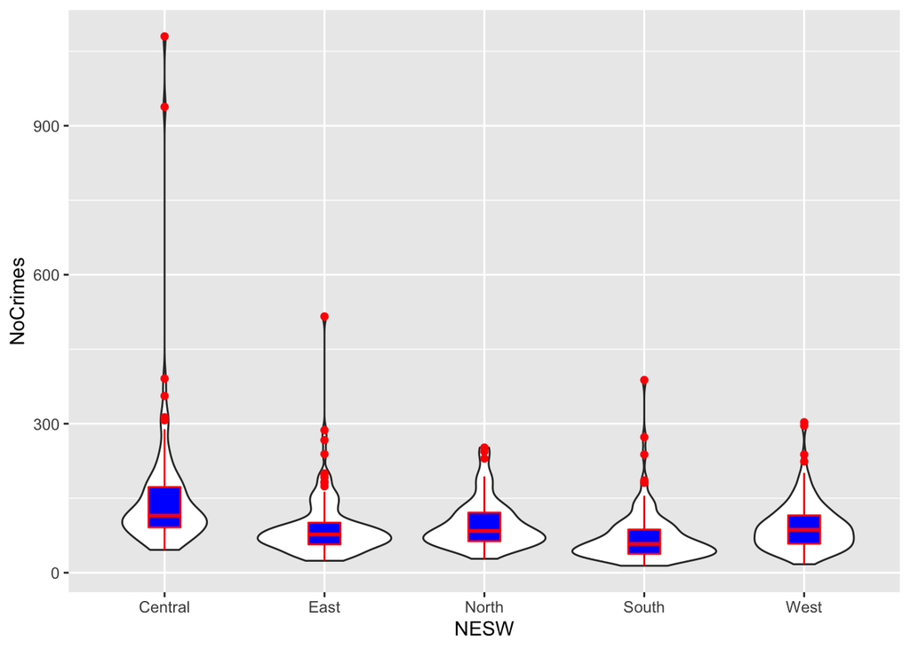

```r
library(ggplot2)
p = ggplot(crime[(crime$year==2016) & (crime$month==8)], aes(x=NESW, y=NoCrimes))
p + geom_violin() + geom_boxplot(width=.2, fill="blue",col="red")
```

Median Imputing for the non logical Number of Employee and Number of crimes

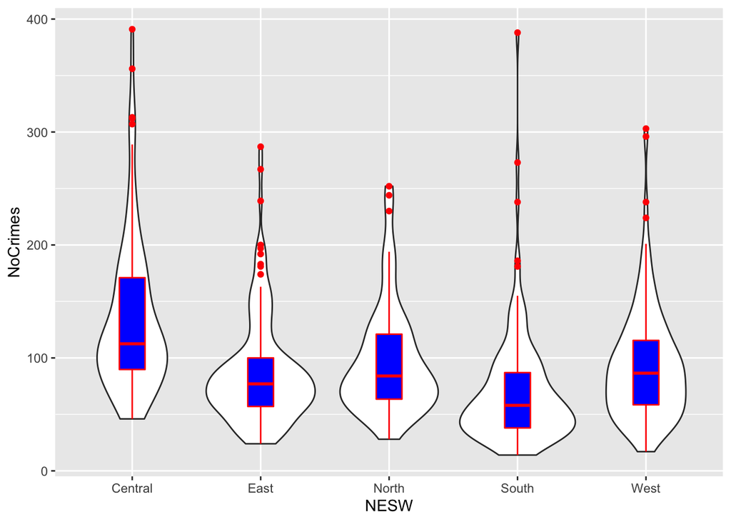

```r
library(outliers)
crime$NoEmployee[crime$Emp_Pcnt[(crime$Emp_Pcnt>0.9) | (crime$Emp_Pcnt<0.1 )]]=median(crime$NoEmployee)
crime$NoCrimes[scores(crime$NoCrimes, type="z", prob=0.9997)]=median(crime$NoCrimes)
p = ggplot(crime[(crime$year==2016) & (crime$month==8)], aes(x=NESW, y=NoCrimes))
p + geom_violin() + geom_boxplot(width=.2, fill="blue",col="red")
```

Factoring non numeric attributes that can be used as input to the machine learning model

```r
crime$NESW = as.factor(crime$NESW)
```

Transforming the non Normalized variables

```r
crime$HousePriceToIncomeRatio=log(crime$HousePriceToIncomeRatio)
crime$NoEmployee=log(crime$NoEmployee)
crime$MedHPrice=log(crime$MedHPrice)
```

Checking the Pearson Correlation between the No of Crimes and the other attributes.

```r
library(psych)
corr.test(crime[, c("year","month","AreaSqKm","lon","lat","IncomeScor","LivingEnSc","NoEmployee","GrenSpace","PopDen","BornUK","NotBornUK","NoCTFtoH","NoDwelling","NoFlats","NoHouses","NoOwndDwel","MedHPrice","HousePriceToIncomeRatio","Pop" )],crime$NoCrimes,adjust = "fdr")
```

```
## Call:corr.test(x = crime[, c("year", "month", "AreaSqKm", "lon", "lat",
##     "IncomeScor", "LivingEnSc", "NoEmployee", "GrenSpace", "PopDen",
##     "BornUK", "NotBornUK", "NoCTFtoH", "NoDwelling", "NoFlats",
##     "NoHouses", "NoOwndDwel", "MedHPrice", "HousePriceToIncomeRatio",
##     "Pop")], y = crime$NoCrimes, adjust = "fdr")
## Correlation matrix
##                          [,1]
## year                     0.04
## month                    0.02
## AreaSqKm                -0.10
## lon                      0.04
## lat                      0.11
## IncomeScor               0.39
## LivingEnSc               0.50
## NoEmployee               0.57
## GrenSpace               -0.23
## PopDen                   0.27
## BornUK                  -0.03
## NotBornUK                0.49
## NoCTFtoH                -0.15
## NoDwelling               0.49
## NoFlats                  0.52
## NoHouses                -0.29
## NoOwndDwel              -0.32
## MedHPrice               -0.04
## HousePriceToIncomeRatio  0.41
## Pop                      0.44
## Sample Size
## [1] 59850
## Probability values  adjusted for multiple tests.
##                         [,1]
## year                       0
## month                      0
## AreaSqKm                   0
## lon                        0
## lat                        0
## IncomeScor                 0
## LivingEnSc                 0
## NoEmployee                 0
## GrenSpace                  0
## PopDen                     0
## BornUK                     0
## NotBornUK                  0
## NoCTFtoH                   0
## NoDwelling                 0
## NoFlats                    0
## NoHouses                   0
## NoOwndDwel                 0
## MedHPrice                  0
## HousePriceToIncomeRatio    0
## Pop                        0
##
##  To see confidence intervals of the correlations, print with the short=FALSE option
```

Visualizing the correlation

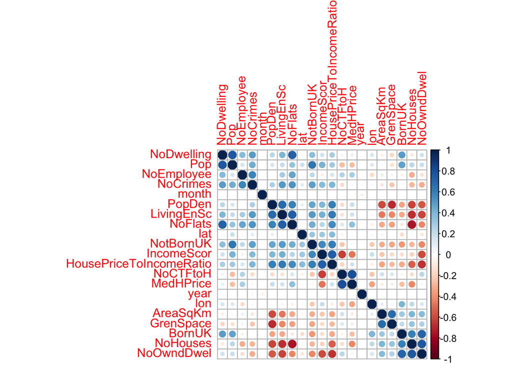

```r
library(corrplot)
mycorr = corr.test(crime[, c("year","month","AreaSqKm","lon","lat","IncomeScor","LivingEnSc","NoEmployee","GrenSpace","PopDen","BornUK","NotBornUK","NoCTFtoH","NoDwelling","NoFlats","NoHouses","NoOwndDwel","MedHPrice","HousePriceToIncomeRatio","Pop","NoCrimes")])
corrplot(mycorr$r,order = "hclust")
```

Visulaizing the highly correlated attributes taking into consideration the reasoning. For example Higly No of EmPloyee is due to High Nmber of Population

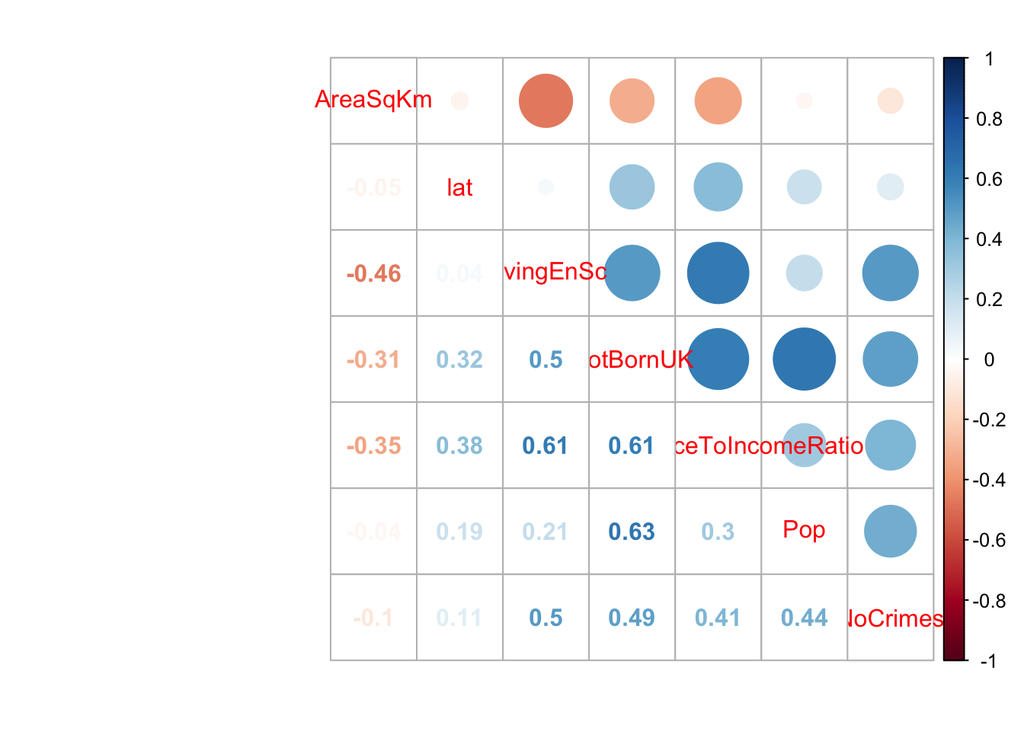

```r
mycorr1 = corr.test(crime[, c("AreaSqKm","lat","LivingEnSc","NotBornUK","HousePriceToIncomeRatio","Pop","NoCrimes")])
corrplot.mixed(mycorr1$r)
```

```r
library(GGally)
```

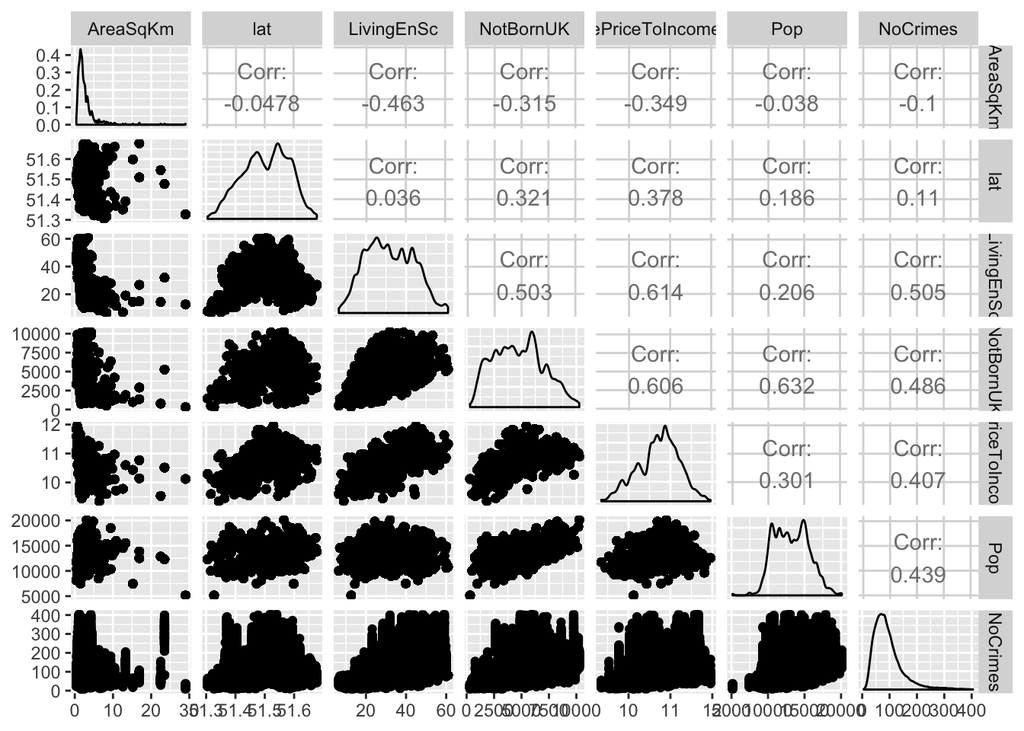

```r
mycorr2 = crime[, c("AreaSqKm","lat","LivingEnSc","NotBornUK","HousePriceToIncomeRatio","Pop","NoCrimes")]
ggpairs(mycorr2)
```

Data Interpetation: From the below Graph we can see People who are not born in uk which High in center and north which interpret the number of crimes increase with NotBornUK and lat.

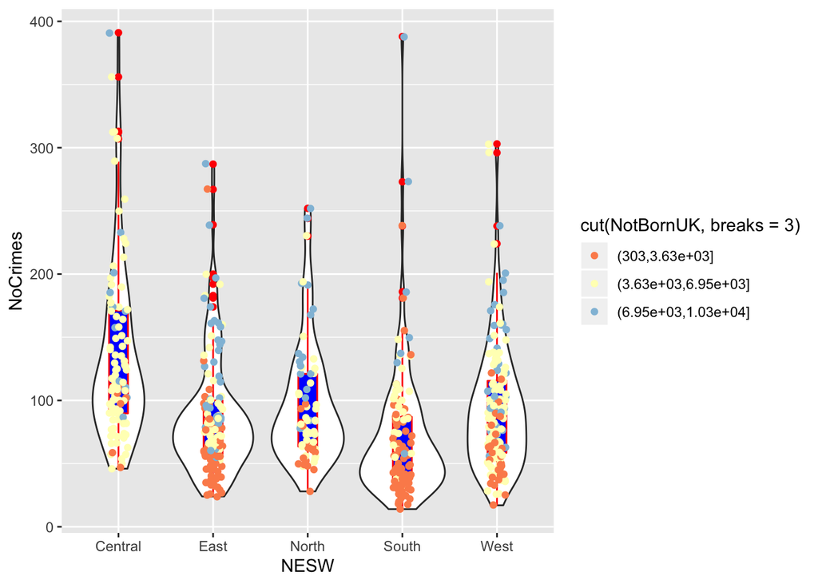

```r
p = ggplot(crime[(crime$year==2016) & (crime$month==8)], aes(x=NESW, y=NoCrimes))
p + geom_violin() + geom_boxplot(width=.2, fill="blue",col="red") +geom_jitter(width=.1,aes(col=cut(NotBornUK,breaks=3)))+scale_color_brewer(type='div', palette=7)
```

Modelling Using Linear Regression to predict the total number of crimes in a given ward, month and year.

```r
trainingRowIndex = sample(1:nrow(crime), 0.8*nrow(crime))
crime1=scale(crime[,c("year","month","lon", "lat", "AreaSqKm","IncomeScor" , "LivingEnSc", "NoEmployee" , "GrenSpace" , "PopDen" , "BornUK" , "NotBornUK" ,"NoCTFtoH" , "NoDwelling" , "NoFlats", "NoHouses" , "NoOwndDwel" ,"MedHPrice" , "Pop" ,"HousePriceToIncomeRatio")])
crime1Train = cbind(crime1,crime[,c("NESW","NoCrimes")])[trainingRowIndex, ]
crime1Test  = cbind(crime1,crime[,c("NESW","NoCrimes")])[-trainingRowIndex, ]
linearModel = lm(NoCrimes ~ (year+month+lat+lon+Pop+PopDen+AreaSqKm+HousePriceToIncomeRatio+NotBornUK+LivingEnSc+NoEmployee+NoDwelling+NoHouses+NoFlats+NoOwndDwel+BornUK+GrenSpace)^2, data=crime1Train)
summary(linearModel)
```

```
##
## Call:
## lm(formula = NoCrimes ~ (year + month + lat + lon + Pop + PopDen +
##     AreaSqKm + HousePriceToIncomeRatio + NotBornUK + LivingEnSc +
##     NoEmployee + NoDwelling + NoHouses + NoFlats + NoOwndDwel +
##     BornUK + GrenSpace)^2, data = crime1Train)
##
## Residuals:
##      Min       1Q   Median       3Q      Max
## -212.520  -15.769   -1.445   13.174  202.233
##
## Coefficients: (1 not defined because of singularities)
##                                      Estimate Std. Error t value Pr(>|t|)
## (Intercept)                         8.254e+01  8.472e-01  97.423  < 2e-16 ***
## year                                1.872e+00  1.299e-01  14.409  < 2e-16 ***
## month                               1.122e+00  1.297e-01   8.649  < 2e-16 ***
## lat                                -4.990e-01  2.899e-01  -1.721 0.085214 .
## lon                                 3.729e+00  3.681e-01  10.130  < 2e-16 ***
## Pop                                 8.830e+01  1.581e+01   5.585 2.35e-08 ***
## PopDen                             -2.703e+01  1.285e+00 -21.040  < 2e-16 ***
## AreaSqKm                           -2.550e+01  2.085e+00 -12.229  < 2e-16 ***
## HousePriceToIncomeRatio             1.053e+00  4.182e-01   2.517 0.011827 *
## NotBornUK                          -6.873e+01  1.512e+01  -4.547 5.47e-06 ***
## LivingEnSc                          5.775e+00  4.041e-01  14.293  < 2e-16 ***
## NoEmployee                          2.286e+01  2.641e-01  86.552  < 2e-16 ***
## NoDwelling                          6.949e+01  1.080e+01   6.437 1.23e-10 ***
## NoHouses                           -4.508e+01  1.134e+01  -3.977 6.98e-05 ***
## NoFlats                            -7.943e+01  1.661e+01  -4.783 1.73e-06 ***
## NoOwndDwel                         -3.120e+01  5.939e-01 -52.526  < 2e-16 ***
## BornUK                             -6.153e+01  1.326e+01  -4.640 3.49e-06 ***
## GrenSpace                          -8.302e+00  3.615e-01 -22.968  < 2e-16 ***
## year:month                          1.172e+00  1.328e-01   8.831  < 2e-16 ***
## year:lat                            6.082e-01  1.598e-01   3.807 0.000141 ***
## year:lon                            1.906e-02  1.652e-01   0.115 0.908146
## year:Pop                           -6.877e+01  1.103e+01  -6.237 4.51e-10 ***
## year:PopDen                         1.547e+00  2.715e-01   5.699 1.21e-08 ***
## year:AreaSqKm                      -8.057e-01  1.916e-01  -4.205 2.61e-05 ***
## year:HousePriceToIncomeRatio        3.955e-01  2.536e-01   1.560 0.118838
## year:NotBornUK                      6.460e+01  1.058e+01   6.104 1.04e-09 ***
## year:LivingEnSc                    -2.303e+00  2.565e-01  -8.981  < 2e-16 ***
```

[output cut: 118 more lines]

```
## NoHouses:NoOwndDwel                -1.037e+02  1.112e+01  -9.326  < 2e-16 ***
## NoHouses:BornUK                    -3.128e+03  3.433e+02  -9.111  < 2e-16 ***
## NoHouses:GrenSpace                 -1.508e+02  8.900e+00 -16.948  < 2e-16 ***
## NoFlats:NoOwndDwel                 -1.461e+02  1.624e+01  -8.998  < 2e-16 ***
## NoFlats:BornUK                     -4.706e+03  4.945e+02  -9.518  < 2e-16 ***
## NoFlats:GrenSpace                  -2.144e+02  1.286e+01 -16.670  < 2e-16 ***
## NoOwndDwel:BornUK                  -1.788e+02  2.756e+01  -6.488 8.78e-11 ***
## NoOwndDwel:GrenSpace                4.352e+00  7.424e-01   5.862 4.61e-09 ***
## BornUK:GrenSpace                   -7.665e+00  2.007e+01  -0.382 0.702495
## ---
## Signif. codes:  0 '***' 0.001 '**' 0.01 '*' 0.05 '.' 0.1 ' ' 1
##
## Residual standard error: 28.29 on 47727 degrees of freedom
## Multiple R-squared:  0.7255, Adjusted R-squared:  0.7246
## F-statistic:   830 on 152 and 47727 DF,  p-value: < 2.2e-16
```

```r
crime1Test$pred = predict(linearModel,crime1Test)
crime1Test$actual = crime1Test[,"NoCrimes"]
library(Metrics)
library(MLmetrics)
R2_Score(crime1Test$actual, crime1Test$pred)
```

```
## [1] 0.6097092
```

```r
RMSE(crime1Test$actual,crime1Test$pred)
```

```
## [1] 28.37672
```

```r
head(crime1Test$pred)
```

```
## [1] 131.9712 131.1825 162.1873 162.3166 130.9516 162.4027
```

```r
head(crime1Test$actual)
```

```
## [1] 226 209 201 217 177 157
```

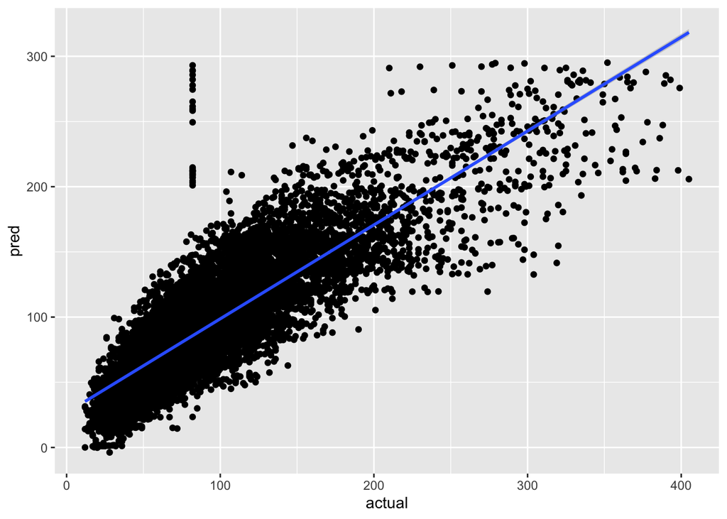

```r
ggplot(crime1Test,aes(x=actual, y=pred))+geom_point() +geom_smooth(method = "lm")
```